# Logbook Jasper Jonker

## 24-09

```bash
cat /students/2024-2025/Thema05/BlaasKanker/SRR_Acc_List.txt | \
    parallel 'samtools index -M /students/2024-2025/Thema05/BlaasKanker/testingtools/BWA_test_vol/output/aln_sorted/{}_sorted.bam'
```

Het werkt zoals het zou moeten en nu even wachten op het trimmen. Hier hebben we nog twijfels over wat we moeten doen met de duplicaten en gaan we dan op 25-09 gaan we het mappen op de echte getrimmde data.

Nu ga ik verder met trimomatic dus kopieer het van boven weer. Deze is de basic dan en word aangepast zodat ik de rest niet in de weg zit.

```bash
cat /students/2024-2025/Thema05/BlaasKanker/SRR_Acc_List.txt | \
  parallel 'TrimmomaticPE -threads 8' \
                  '/students/2024-2025/Thema05/BlaasKanker/testdata/{}_1.fastq' \
                  '/students/2024-2025/Thema05/BlaasKanker/testdata/{}_2.fastq' \
                  '/students/2024-2025/Thema05/BlaasKanker/testingtools/trim_jasper/paired/{}_paired.1.fastq' \
                  '/students/2024-2025/Thema05/BlaasKanker/testingtools/trim_jasper/unpaired/{}_unpaired.1.fastq' \
                  '/students/2024-2025/Thema05/BlaasKanker/testingtools/trim_jasper/paired/{}_paired.2.fastq' \
                  '/students/2024-2025/Thema05/BlaasKanker/testingtools/trim_jasper/unpaired/{}_unpaired.2.fastq' \
                  'SLIDINGWINDOW:4:20' \
                  'MINLEN:40'
```

Ik maak ook gelijk dit om de fastqc

```bash
fastqc /students/2024-2025/Thema05/BlaasKanker/testingtools/trim_jasper/paired/* \
    -o /students/2024-2025/Thema05/BlaasKanker/testingtools/trim_jasper/FASTqc/
```

Ik maak ook hier een multiqc

```bash
multiqc /students/2024-2025/Thema05/BlaasKanker/testingtools/trim_jasper/FASTqc/* -o /students/2024-2025/Thema05/BlaasKanker/testingtools/trim_jasper/MUL/
```

Het is verkeerd gegaan alles is leeg dus ik doe het nu opnieuw. Ik had een spelfout gemaakt in de trimmomatic dus dat is gefikst

```bash
cat /students/2024-2025/Thema05/BlaasKanker/SRR_Acc_List.txt | \
  parallel 'TrimmomaticPE -threads 8' \
                  '/students/2024-2025/Thema05/BlaasKanker/testdata/{}_1.fastq' \
                  '/students/2024-2025/Thema05/BlaasKanker/testdata/{}_2.fastq' \
                  '/students/2024-2025/Thema05/BlaasKanker/testingtools/trim_jasper/paired/{}_paired.1.fastq' \
                  '/students/2024-2025/Thema05/BlaasKanker/testingtools/trim_jasper/unpaired/{}_unpaired.1.fastq' \
                  '/students/2024-2025/Thema05/BlaasKanker/testingtools/trim_jasper/paired/{}_paired.2.fastq' \
                  '/students/2024-2025/Thema05/BlaasKanker/testingtools/trim_jasper/unpaired/{}_unpaired.2.fastq' \
                  'SLIDINGWINDOW:4:20' \
                  'MINLEN:40' \
```

Hier heb je mijn resultaten

[figure not shown]

[figure not shown]

hier zie je dat de data over het algemeen goed is behalve Sequence Length Distribution maar dat gebeurt al snel en kan je niet veel doen. ## 25-09

Uit Ramons github heb ik `-M -R '@RG\\tID:{}\\tSM:{}\\tPL:illumina\\tLB:lib1` gehaald. Dit zorgt ervoor dat bwa de duplicaten highlight als het ware en dat is nodig voor picard om het te doen

```bash
cat /students/2024-2025/Thema05/BlaasKanker/SRR_Acc_List.txt | \
  parallel -j 20 "bwa mem -t 15 -M -R '@RG\\tID:{}\\tSM:{}\\tPL:illumina\\tLB:lib1' \
    /students/2024-2025/Thema05/BlaasKanker/outputs/bwa_aln/index/GCF_000001635.27_GRCm39_genomic.fna \
    /students/2024-2025/Thema05/BlaasKanker/outputs/fastq_trimmed/{}_paired.1.fastq /students/2024-2025/Thema05/BlaasKanker/outputs/fastq_trimmed/{}_paired.2.fastq > \
    /students/2024-2025/Thema05/BlaasKanker/outputs/bwa_aln/mapping_output/{}.sam"
```

## 26-09

Na controle van de data ga ik vandaag mappen. Ik was de laatste stappen vergeten toe te voegen maar het werkt nu als het goed is

```bash
cat /students/2024-2025/Thema05/BlaasKanker/SRR_Acc_List.txt | \
  parallel "samtools view -b /students/2024-2025/Thema05/BlaasKanker/outputs/bwa_aln/mapping_output/{}.sam > {}.bam"\
cat /students/2024-2025/Thema05/BlaasKanker/SRR_Acc_List.txt | \
  parallel "samtools view -b /students/2024-2025/Thema05/BlaasKanker/outputs/bwa_aln/mapping_output/{}.sam | samtools sort -o /students/2024-2025/Thema05/BlaasKanker/outputs/bwa_aln/mapping_output/sorted/{}_sorted.bam"
cat /students/2024-2025/Thema05/BlaasKanker/SRR_Acc_List.txt | \
  parallel -j 6 "samtools index /students/2024-2025/Thema05/BlaasKanker/outputs/bwa_aln/mapping_output/sorted/{}_sorted.bam"
```

oefen data maken voor iris voor twee bestanden. Zodat zij verder kan werken en het niet perse op echte data het moet proberen

```bash
cat /students/2024-2025/Thema05/BlaasKanker/SRR_Acc_List.txt | \
  parallel -j 20 "bwa mem -t 15 -M -R '@RG\\tID:{}\\tSM:{}\\tPL:illumina\\tLB:lib1' \
    /students/2024-2025/Thema05/BlaasKanker/outputs/bwa_aln/index/GCF_000001635.27_GRCm39_genomic.fna \
 /students/2024-2025/Thema05/BlaasKanker/testingtools/bwatesten/SRR14870694_1.fastq /students/2024-2025/Thema05/BlaasKanker/testingtools/bwatesten/SRR14870694_2.fastq > \
    /students/2024-2025/Thema05/BlaasKanker/testingtools/bwatesten/outputtest.sam"
samtools view -b /students/2024-2025/Thema05/BlaasKanker/testingtools/bwatesten/outputtest.sam > /students/2024-2025/Thema05/BlaasKanker/testingtools/bwatesten/outputtest.bam
samtools view -b /students/2024-2025/Thema05/BlaasKanker/testingtools/bwatesten/outputtest.sam > /students/2024-2025/Thema05/BlaasKanker/testingtools/bwatesten/outputtest.bam
samtools sort -o /students/2024-2025/Thema05/BlaasKanker/testingtools/bwatesten/outputtest.sorted.bam /students/2024-2025/Thema05/BlaasKanker/testingtools/bwatesten/outputtest.bam

samtools index /students/2024-2025/Thema05/BlaasKanker/testingtools/bwatesten/outputtest.sorted.bam
```

## 27-09

Ik heb de data nu goed gemaakt was blijkbaar niet goed gegaan waarschijnlijk door de slechte servers. Want ik kreeg geen fout meldingen of wat dan ook

Ik ga nu weer nieuwe testdata maken van alle testdata. zodat iris er mee bezig kan. Die heeft mijn data nodig om haar tool, Picard, te kunnen gebruiken. Picard is een tool die nodig is om duplicaten te markeren.

```bash
cat /students/2024-2025/Thema05/BlaasKanker/SRR_Acc_List.txt | \
  parallel -j 20 "bwa mem -t 20 -M -R '@RG\\tID:{}\\tSM:{}\\tPL:illumina\\tLB:lib1' \
    /students/2024-2025/Thema05/BlaasKanker/outputs/bwa_aln/index/GCF_000001635.27_GRCm39_genomic.fna \
    /students/2024-2025/Thema05/BlaasKanker/testdata/{}_1.fastq /students/2024-2025/Thema05/BlaasKanker/testdata/{}_2.fastq > \
    /students/2024-2025/Thema05/BlaasKanker/testingtools/bwatesten/output_sam/{}.sam"

cat /students/2024-2025/Thema05/BlaasKanker/SRR_Acc_List.txt | \
  parallel "samtools view -b /students/2024-2025/Thema05/BlaasKanker/testingtools/bwatesten/output_sam/{}.sam | samtools sort -o /students/2024-2025/Thema05/BlaasKanker/testingtools/bwatesten/output_sorted_bam/{}_sorted.bam"

cat /students/2024-2025/Thema05/BlaasKanker/SRR_Acc_List.txt | \
  parallel -j 6 "samtools index /students/2024-2025/Thema05/BlaasKanker/testingtools/bwatesten/output_sorted_bam/{}_sorted.bam"
```

Dat is gelukt dus we kunnen weer verder.

Iris heeft picard gebruikt om de duplicaten te verwijderen. Ze heeft het eerst op de test data gedaan en later die dag op de echte data. Dit is te lezen in het logboek van Iris

Hier is het stukje code wat gebruikt is voor Picard

```bash
cat /students/2024-2025/Thema05/BlaasKanker/SRR_Acc_List.txt | \
  parallel java -jar picard.jar MarkDuplicates \
                '-I /students/2024-2025/Thema05/BlaasKanker/outputs/bwa_aln/mapping_output/sorted/{}_sorted.bam' \
                '-O /students/2024-2025/Thema05/BlaasKanker/outputs/picard_dub/marked_duplicates/{}.marked_duplicates.bam' \
                '-M /students/2024-2025/Thema05/BlaasKanker/outputs/picard_dub/metrics/{}.marked_dup_metrics.txt' \
                '-REMOVE_DUPLICATES true' \
                '-READ_NAME_REGEX null'
```

```bash
cat /students/2024-2025/Thema05/BlaasKanker/SRR_Acc_List.txt | \
    parallel "lofreq call \
    -f /students/2024-2025/Thema05/BlaasKanker/outputs/bwa_aln/index/GCF_000001635.27_GRCm39_genomic.fna \
    -o /students/2024-2025/Thema05/BlaasKanker/testingtools/test_variant_calling/{}_variants.vcf \
    /students/2024-2025/Thema05/BlaasKanker/testingtools/picard_test/poging_1/{}.marked_duplicates.bam"
```

## 01-10

lofreq uitgevoerd dat kan je allemaal lezen in het Logboek van Ramon.

Hier is de code die hij daar heeft gebruikt.

```bash
cat /students/2024-2025/Thema05/BlaasKanker/SRR_Acc_List.txt | \
    parallel "lofreq call \
    -f /students/2024-2025/Thema05/BlaasKanker/outputs/bwa_aln/index/GCF_000001635.27_GRCm39_genomic.fna \
    -o /students/2024-2025/Thema05/BlaasKanker/outputs/variant_calling_unfiltered/{}_variants.vcf \
    --verbose \
    /students/2024-2025/Thema05/BlaasKanker/outputs/picard_dub/marked_duplicates/{}.marked_duplicates.bam"
```

## 03-10

snpeff is uitgevoerd en is te lezen in het logbook van Ramon.

hier is de code

```bash
cat /students/2024-2025/Thema05/BlaasKanker/SRR_Acc_List.txt | \
    parallel -j 6 \
    "java -Xmx8g -jar /students/2024-2025/Thema05/BlaasKanker/tools/snpeff/snpEff/snpEff.jar ann -v -stats \
    /students/2024-2025/Thema05/BlaasKanker/outputs/variant_annotation/stats.html mm39 \
    /students/2024-2025/Thema05/BlaasKanker/outputs/chromosome_remade_varients/{}_variants.vcf > /students/2024-2025/Thema05/BlaasKanker/outputs/variant_annotation/{}.vcf"
```

## 04-10

Ik ga GSEA bekijken en downloaden. GSEA is een tool waar je mee kan kijken of vooraf gedefinieerde set genen significant, overeenstemde verschillen heeft onder 2 verschillende biologische processen. Hiermee kunnen we kijken wat voor invloed de mutaties hebben. We gaan het nu nog niet gebruiken. Dat komt omdat we nu nog niet weten wat de bedoeling is met de eind bestanden die we hebben gemaakt.

Nu ga ik dus bezig met vcfstats. Dit om de vcf bestanden te laten zien.

```bash
# om vcfstats te downloaden
pip install -U vcfstats
```

Hieronder is het command voor op de data gelijk op een oefen pagina op alle sequenties

```bash
cat /students/2024-2025/Thema05/BlaasKanker/SRR_Acc_List.txt | \
parallel "vcfstats --vcf /students/2024-2025/Thema05/BlaasKanker/outputs/variant_ann_sorted/{}_sorted.vcf\
    --outdir /students/2024-2025/Thema05/BlaasKanker/testingtools/vcfstatsoefen/ \
    --formula 'COUNT(1) ~ CONTIG' \
    --title 'Number of variants on each chromosome({})'"
```

Hier doen we het op de mutaties die overblijven die een mutaties hebben die dan vervolgens kanker kunnen veroorzaken.

```bash
cat /students/2024-2025/Thema05/BlaasKanker/SRR_Acc_List.txt | \
parallel "vcfstats --vcf /students/2024-2025/Thema05/BlaasKanker/outputs/variant_annotation_cancer_genes/{}.vcf\
    --outdir /students/2024-2025/Thema05/BlaasKanker/testingtools/vcfstatsoefen/cancer/ \
    --formula 'COUNT(1) ~ CONTIG' \
    --title 'Number of variants on each chromosome(kanker)({})'"
```

Hieronder zie je de twee figuren van hetzelfde sample. De linker zijn alle varianten en de rechter zijn alle varianten die kanker veroorzaken.

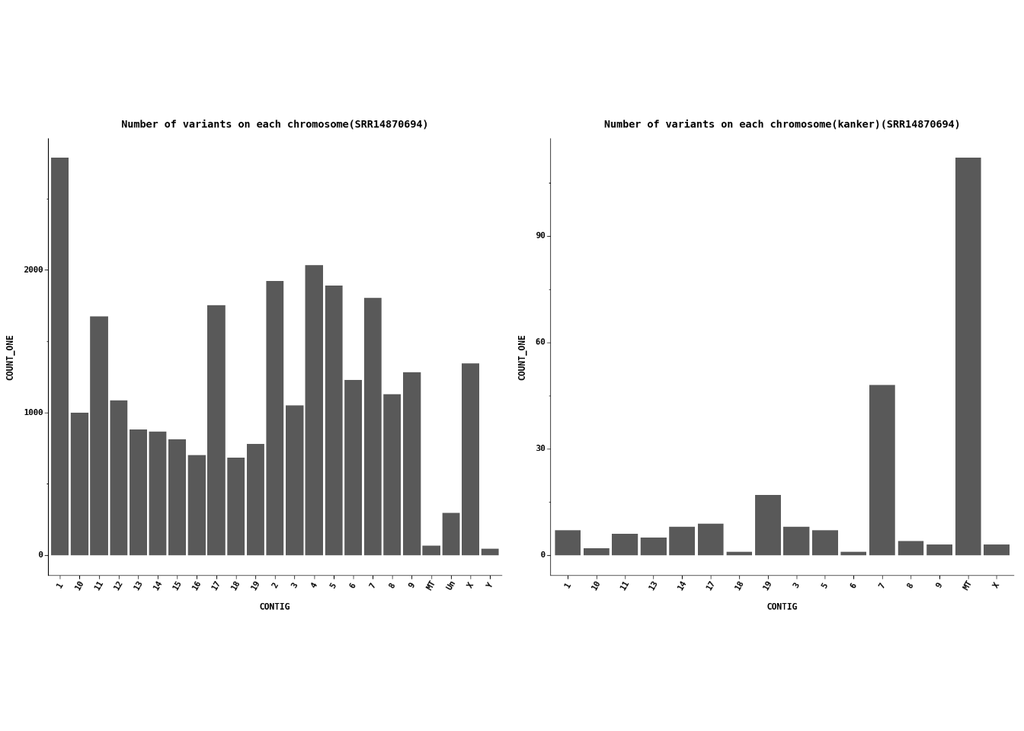

## De rest

Deze periode ben ik bezig geweest met mensen helpen bijvoorbeeld met de plots maken en alvast bezig geweest met het plan van aanpak voor het trimmomatic gedeelte.

GSA wordt niet meer gebruikt misschien nog in het trimmomatic gedeelte. Want we dachten dat we een verslag moesten schrijven maar dat is niet nodig, alleen maar de loliplot maken.

Met deze loliplot willen we laten zien welke varianten er zijn, of ze op een intron liggen of op een exon liggen en uiteindelijk laten zien wat voor invloed ze hebben op hun processen.

Hiervoor laat ik eerst de bestanden in die ik nodig ga hebben

```r
snp_data <- read.csv2("/students/2024-2025/Thema05/BlaasKanker/outputs/vcf_ann_snpSift/SRR14870694.vcf.tabular", sep = "\t", na.strings = "unkown")

bed_file <- read.table("/students/2024-2025/Thema05/BlaasKanker/etc/filtered_bed.bed")
names(bed_file) <- c("chromosome", "exon_start", "exon_end", "gene_name")
```

Nu ga ik granges maken dat is belangrijke basis voor [Genomische locatie](https://bioconductor.org/packages/devel/bioc/vignettes/GenomicRanges/inst/doc/GenomicRangesIntroduction.html) Wat hier wordt gedaan is elk object de exonen regio’s van een specifiek gen bevat en elke de start- en eindposities van de exonen te bepalen

```r
list_granges <- list()
bed_splitted = split(bed_file, bed_file$gene_name)
for (gene in names(bed_splitted)){
        ranges <- IRanges(start = bed_splitted[[gene]]$exon_start,
                      end = bed_splitted[[gene]]$exon_end,
                      names = bed_splitted[[gene]]$gene_name)

    granges = GRanges(seqnames = bed_splitted[[gene]]$chromosome,
                      ranges = ranges)
    mcols(granges)$gene_name = gene
    list_granges[[gene]] <- granges
}
list_granges <- GRangesList(list_granges)
list_granges
```

```
## GRangesList object of length 179:
## $Amacr
## GRanges object with 9 ranges and 1 metadata column:
##         seqnames            ranges strand |   gene_name
##            <Rle>         <IRanges>  <Rle> | <character>
##   Amacr    chr15 10981841-10982139      * |       Amacr
##   Amacr    chr15 10983435-10983579      * |       Amacr
##   Amacr    chr15 10984771-10984932      * |       Amacr
##   Amacr    chr15 10988844-10989031      * |       Amacr
##   Amacr    chr15 10994925-10996712      * |       Amacr
##   Amacr    chr15 10983491-10983579      * |       Amacr
##   Amacr    chr15 10984742-10984932      * |       Amacr
##   Amacr    chr15 10988844-10989031      * |       Amacr
##   Amacr    chr15 10994925-10995093      * |       Amacr
##   -------
##   seqinfo: 21 sequences from an unspecified genome; no seqlengths
##
## ...
## <178 more elements>
```

voor genetische varianten die zijn geannoteerd in een VCF-bestand

```r
list_variant_ranges <- list()

# Doorloop alle unieke genen
for (gene_vcf in unique(snp_data$ANN....GENE)) {

    # Selecteer de posities en impact voor het huidige gen
    gene_data <- snp_data[snp_data$ANN....GENE == gene_vcf, ]

    # Maak de IRanges voor de SNP's
    vcf_range <- IRanges(
        start = gene_data$POS,
        end = gene_data$POS,
        names = gene_vcf,
        impact = gene_data$ANN....IMPACT
    )

    # Maak het GRanges object voor de SNP's
    vcf_grange <- GRanges(
        seqnames = unique(gene_data$CHROM),  # Chromosoom is voor elke variant hetzelfde
        ranges = vcf_range
    )

    # Voeg het GRanges object toe aan de lijst
    list_variant_ranges[[gene_vcf]] <- vcf_grange
}

# Zet de lijst om naar een GRangesList object
list_variant_ranges <- GRangesList(list_variant_ranges)

# Toon het resultaat
list_variant_ranges
```

```
## GRangesList object of length 133:
## $Tmeff2
## GRanges object with 3 ranges and 1 metadata column:
##          seqnames    ranges strand |      impact
##             <Rle> <IRanges>  <Rle> | <character>
##   Tmeff2        1  50967280      * |        HIGH
##       NA        1  50967280      * |        HIGH
##       NA        1  51110509      * |    MODIFIER
##   -------
##   seqinfo: 16 sequences from an unspecified genome; no seqlengths
##
## ...
## <132 more elements>
```

Dit blok maakt een lijst van genen die zowel in je VCF-gegevens (snp_data$ANN….GENE) als in de bed_splitted lijst voorkomen.

```r
gene_variants <- unique(snp_data$ANN....GENE[snp_data$ANN....GENE %in% names(bed_splitted)])
gene_variants
```

```
##  [1] "Tmeff2"    "Slc11a1"   "Bcl2"      "Il2"       "Tlr2"      "Gstm3"
##  [7] "Gstm2"     "Gstm1"     "Fgfr3"     "Kdr"       "Chek2"     "Serpine1"
## [13] "Pms2"      "Kras"      "Plk1"      "Fgfr2"     "Hras"      "Muc5b"
## [19] "Nat2"      "Cdh13"     "Fanca"     "Mre11a"    "Cdc25a"    "Timp3"
## [25] "Cdk4"      "Map2k4"    "Erbb2"     "Brca1"     "Mtr"       "Dapk1"
## [31] "Fhit"      "Tnfrsf10b" "Rb1"       "Axin1"     "Msh2"      "Fgf1"
## [37] "Gstp1"     "Gstp2"     "Gstp3"     "Pten"      "Fas"       "Cyp2c65"
## [43] "Cyp2c66"   "Cyp2c29"   "Cyp2c38"   "Cyp2c39"   "Cyp2c50"   "mt-Nd2"
## [49] "mt-Atp8"   "mt-Cytb"   "Kdm6a"
```

Dit blok maakt een lijst van GRanges objecten, waarbij elke entry een GRanges object is voor de exons van een specifiek gen.

```r
list_exons <- list()

for (gene in unique(snp_data$ANN....GENE)){
    if (gene %in% names(bed_splitted)) {
        ranges <- IRanges(start = bed_splitted[[gene]]$exon_start,
                          end = bed_splitted[[gene]]$exon_end,
                          names = bed_splitted[[gene]]$gene_name)

        granges <- GRanges(seqnames = bed_splitted[[gene]]$chromosome,
                           ranges = ranges)

        list_exons[[gene]] <- granges
    }
}

list_exons <- GRangesList(list_exons)
```

Hier maak ik een loliplot

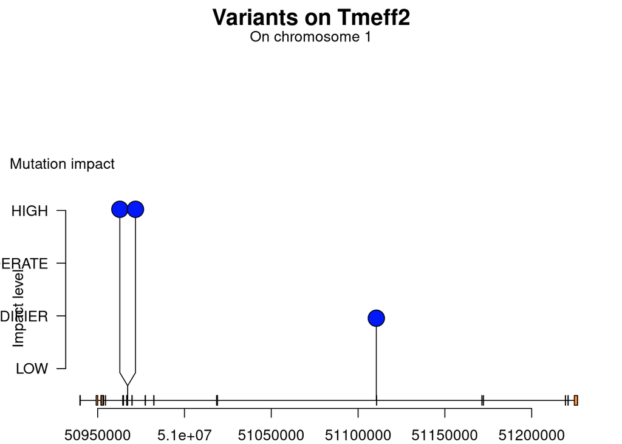

```r
# Selecteer het eerste gen uit gene_variants
gene <- gene_variants[[1]]

# Verkrijg de exons posities (start en end)
exon_end <- end(list_exons[[gene]])
exon_start <- start(list_exons[[gene]])
exon_length <- exon_end - exon_start

# Verkrijg de variant informatie voor dit gen
variant_info <- list_variant_ranges[[gene]]
SNPs <- start(variant_info)
chromosome <- unique(snp_data$CHROM[snp_data$ANN....GENE == gene])

# Maak een hoogte-kaart voor de variant impact
height_map <- c("LOW" = 1, "MODIFIER" = 5, "MODERATE" = 10, "HIGH" = 15)

# Maak GRanges voor de SNPs met impact scores
sample_gr <- GRanges(
  seqnames = chromosome,
  ranges = IRanges(start = SNPs, width = 1),
  names = paste0("SNP_", SNPs)
)
sample_gr$impact <- variant_info$impact

# Zorg ervoor dat de impact wordt omgezet naar een score
sample_gr$score <- height_map[as.character(sample_gr$impact)]
sample_gr$score[is.na(sample_gr$score)] <- 0  # Zet ongeldige waarden om naar 0
sample_gr$color <- "#0118F9"  # Blauw voor de SNPs

# Maak GRanges voor de exons van het gen
gr_exons <- GRanges(
  seqnames = chromosome,
  ranges = IRanges(start = exon_start, end = exon_end)
)
gr_exons$fill <- "#FF8833"  # Oranje voor de exons
gr_exons$height <- unit(3, "mm")

# Instellen van de y-as voor impact niveaus
yaxis <- c(0, 5, 10, 15)
names(yaxis) <- c("LOW", "MODIFIER", "MODERATE", "HIGH")

# Genereer de lollipop plot
lolliplot(
  sample_gr, gr_exons,
  ylab = "Impact level",
  xlab = "Chromosome position",
  yaxis = yaxis
)

# Voeg tekst toe aan de plot
grid.text("Mutation impact", x = 0.1, y = 0.62, just = "bottom", gp = gpar(cex = 1))
grid.text(paste("Variants on", gene), x = 0.5, y = 0.98, just = "top", gp = gpar(cex = 1.5, fontface = "bold"))
grid.text(paste("On chromosome", chromosome), x = 0.5, y = 0.93, just = "top", gp = gpar(cex = 1))
```

Hier zie je dat Tmeff2 een aantal varianten heeft in en buiten een exon. Dit kan gevolgen hebben op het uiteindelijk eiwit waar Tmeff2 voor codeert.

Als we meer tijd hadden gehad zouden we dit kunnen verder kijken wat voor gevolgen het heeft op het uiteindelijke biologische proces.

Ik ga kijken naar alternatieven voor bwa. bwa word vaak gebruikt bij variant analyse omdat hij beter wekt met indels, robuust is en ondersteund veel varianten(ik dedoel hier meer SNPs, indels en structurele varianten). En heeft BWA-MEM is goed voor lange reads.

Een andere is bowtie2. Bowtie2 is hier niet de juiste voor dit onderzoek, want werkt niet goed met indels, maar kan wel gebruikt worden. Bowtie2 word gebruikt voor uitlijnen van korte sequenties tegen het referentie genoom. Maar hij is super snel dus altijd handig om weten hoe het werkt.

Je moet zelf een index maken voor bowtie2 en dat doe je op de volgende manier.

```bash
bowtie2-build /students/2024-2025/Thema05/BlaasKanker/outputs/bwa_aln/index/GCF_000001635.27_GRCm39_genomic.fna \
/students/2024-2025/Thema05/BlaasKanker/outputs/bwa_aln/GCF_000001635.27_GRCm39_genomic
```

Daarna kan je het bowtie2 gebruiken op de volgende manier.

```bash
cat /students/2024-2025/Thema05/BlaasKanker/SRR_Acc_List.txt | \
  parallel -j 20 "bowtie2 -p 15 --very-sensitive -x \
    /students/2024-2025/Thema05/BlaasKanker/outputs/bwa_aln/GCF_000001635.27_GRCm39_genomic \
    -1 /students/2024-2025/Thema05/BlaasKanker/testdata/{}_1.fastq \
    -2 /students/2024-2025/Thema05/BlaasKanker/testdata/{}_2.fastq \
    -S /students/2024-2025/Thema05/BlaasKanker/testingtools/bwatesten/{}.sam"
```

je rkijgt vervolgens dit te zien 500000 reads; of these: 500000 (100.00%) were paired; of these: 11868 (2.37%) aligned concordantly 0 times 331498 (66.30%) aligned concordantly exactly 1 time 156634 (31.33%) aligned concordantly >1 times 11868 pairs aligned concordantly 0 times; of these: 5031 (42.39%) aligned discordantly 1 time 6837 pairs aligned 0 times concordantly or discordantly; of these: 13674 mates make up the pairs; of these: 4639 (33.93%) aligned 0 times 3733 (27.30%) aligned exactly 1 time 5302 (38.77%) aligned >1 times

Het grootste deel van je data (66.3%) heeft zich correct uitgelijnd op het genoom (exact 1 keer).

Ongeveer 31.3% van de reads is meer dan één keer uitgelijnd, wat wijst op mogelijke repetitieve regio’s of ambiguïteit in de data.

De discordante uitlijningen (42.39%) kunnen wijzen op interessante structuren of variaties, maar zouden verder moeten worden onderzocht.

Hierna moet je nog wel bezig met samtools.

```bash
cat /students/2024-2025/Thema05/BlaasKanker/SRR_Acc_List.txt | \
  parallel -j 20 "samtools view -b /students/2024-2025/Thema05/BlaasKanker/testingtools/bwatesten/{}.sam > /students/2024-2025/Thema05/BlaasKanker/testingtools/bwatesten/{}.bam"

cat /students/2024-2025/Thema05/BlaasKanker/SRR_Acc_List.txt | \
  parallel -j 20 "samtools sort -o /students/2024-2025/Thema05/BlaasKanker/testingtools/bwatesten/sorted_bam/{}.sorted.bam /students/2024-2025/Thema05/BlaasKanker/testingtools/bwatesten/{}.bam"

cat /students/2024-2025/Thema05/BlaasKanker/SRR_Acc_List.txt | \
  parallel -j 20  "samtools index /students/2024-2025/Thema05/BlaasKanker/testingtools/bwatesten/sorted_bam/{}.sorted.bam"
```

Dus bowtie2 is een handige tool om te kunnen gebruiken. Ik vond de statistiek in de terminal te voorschijn komt ook erg prettig dan weet je het ook og je het goed doet. Het is alleen niet handig voor dit onderzoek maar wel handig als je het snel nodig hebt.